# IODS COURSE PROJECT

sani saha

# about the course

this course is so interesting and i am already loving this course.

[GitHub repository](https://github.com/sanisaha/IODS-project)

# regression Analysis

1

```r
mydata <- read.table("http://s3.amazonaws.com/assets.datacamp.com/production/course_2218/datasets/learning2014.txt", sep = ",", header=TRUE)
str(mydata)
```

```
## 'data.frame':    166 obs. of  7 variables:
##  $ gender  : Factor w/ 2 levels "F","M": 1 2 1 2 2 1 2 1 2 1 ...
##  $ age     : int  53 55 49 53 49 38 50 37 37 42 ...
##  $ attitude: num  3.7 3.1 2.5 3.5 3.7 3.8 3.5 2.9 3.8 2.1 ...
##  $ deep    : num  3.58 2.92 3.5 3.5 3.67 ...
##  $ stra    : num  3.38 2.75 3.62 3.12 3.62 ...
##  $ surf    : num  2.58 3.17 2.25 2.25 2.83 ...
##  $ points  : int  25 12 24 10 22 21 21 31 24 26 ...
```

```r
dim(mydata)
```

```
## [1] 166   7
```

the dataset(mydata) has 166 observation and 7 variables. It has 7 columns where points column has all the observation greater than 0.

2

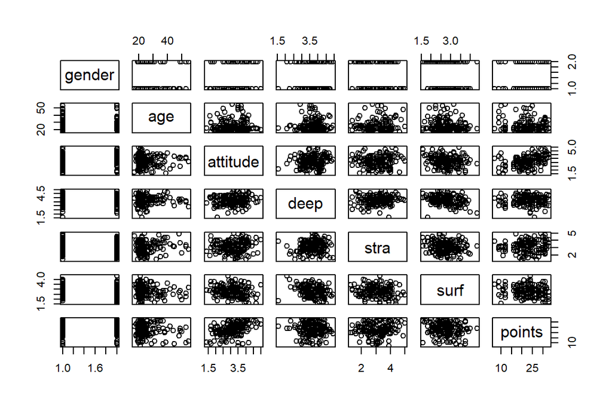

```r
plot(mydata)
```

we can show the data as a scatter plot. It gives a graphical overview of our data. But it is very difficult to make conclusion of the whole data as gender column has no numerical value, otherwise histogram or barplot will be good function for describing the data. we can describe the variables separately or may be as a comparison to other variables by following way.

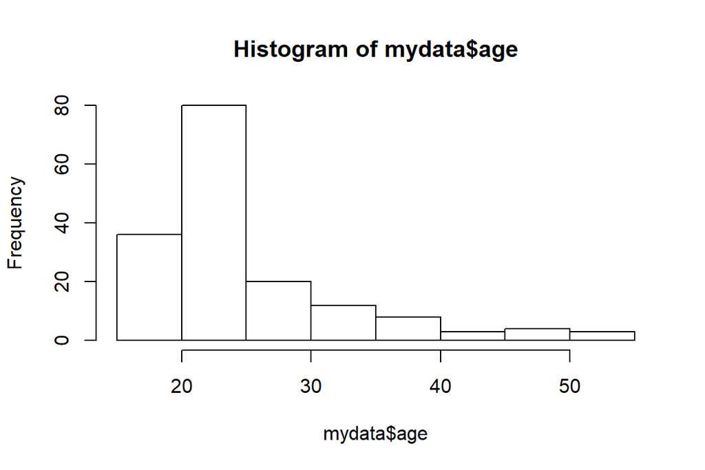

```r
hist(mydata$age)
```

from histogram of age variables we can say that, most of the obervations were age between 20-25.

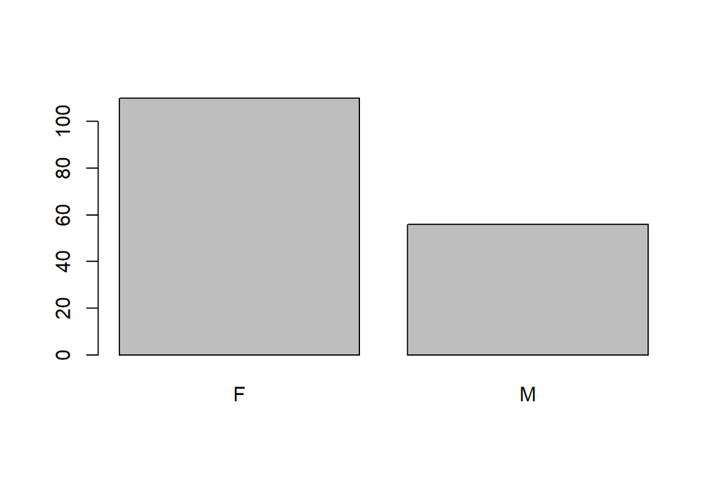

```r
plot(mydata$gender)
```

by ploting gender with plot function we can say that most of the observation was females.

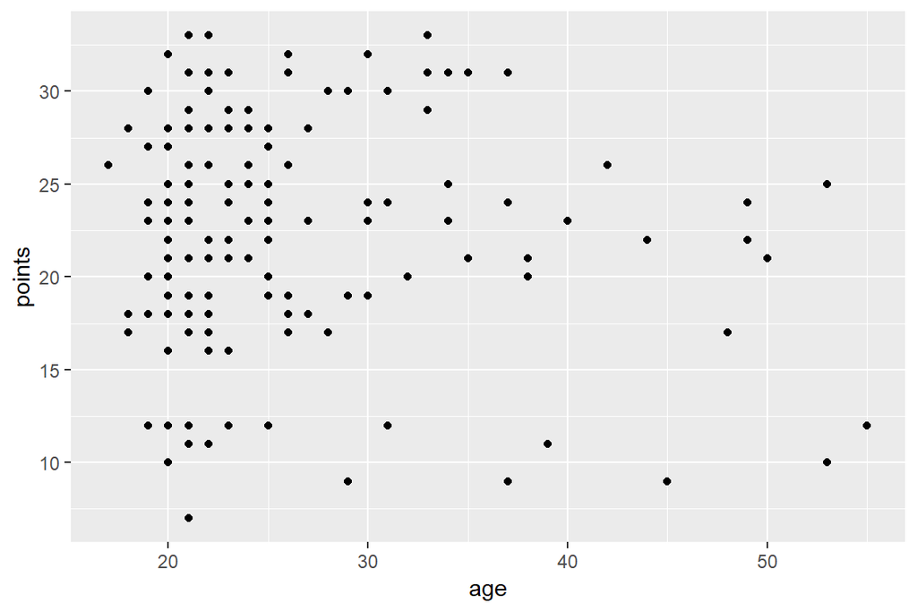

```r
library(ggplot2)
p1 <- ggplot(mydata, aes(x = age, y = points))
p2 <- p1 + geom_point()
p2
```

throgh ggplot2 we can compare 2 variables at a time, here we can see that most the observations were from 20-25 age and they obtain different number of points. those are older than 50 get comparatavely less mark but their number is very small. similarly we can do it for other variables too.

3

```r
RM <- lm(points ~ gender + attitude +  stra, data = mydata)
summary(RM)
```

```
##
## Call:
## lm(formula = points ~ gender + attitude + stra, data = mydata)
##
## Residuals:
##      Min       1Q   Median       3Q      Max
## -17.7179  -3.3285   0.5343   3.7412  10.9007
##
## Coefficients:
##             Estimate Std. Error t value Pr(>|t|)
## (Intercept)   8.9798     2.4030   3.737 0.000258 ***
## genderM      -0.2236     0.9248  -0.242 0.809231
## attitude      3.5100     0.5956   5.893 2.13e-08 ***
## stra          0.8911     0.5441   1.638 0.103419
## ---
## Signif. codes:  0 '***' 0.001 '**' 0.01 '*' 0.05 '.' 0.1 ' ' 1
##
## Residual standard error: 5.304 on 162 degrees of freedom
## Multiple R-squared:  0.2051, Adjusted R-squared:  0.1904
## F-statistic: 13.93 on 3 and 162 DF,  p-value: 3.982e-08
```

here points is the target or dependent variable. gender,attitude and stra are the independent or explanatory variable. Here, Multiple R-squared value is 0.2051 which means about 21% variation in points can be explained by our model (explained by gender, attitude and stra). Here, by F-statistics and p-value we can know the overall significance of our model. By the Residual standard error we can know how much differences in observed and predicted value of target variable(points).we found estimate value of Intercept is 8.9798, which meand the value of points is 8.9798 when all the value of explanatory variables are 0. estimate value of gender is -0.2236, which means for 1year increase in gender, points decrease by 0.2236. Although here p-value is very high and we can say that there is no relationship between gender and points.

In our model only attitude is highly significant. Gender has the least significance among three values. so, let’s try removing gender from our model

```r
RM <- lm(points ~ attitude +  stra, data = mydata)
summary(RM)
```

```
##
## Call:
## lm(formula = points ~ attitude + stra, data = mydata)
##
## Residuals:
##      Min       1Q   Median       3Q      Max
## -17.6436  -3.3113   0.5575   3.7928  10.9295
##
## Coefficients:
##             Estimate Std. Error t value Pr(>|t|)
## (Intercept)   8.9729     2.3959   3.745  0.00025 ***
## attitude      3.4658     0.5652   6.132 6.31e-09 ***
## stra          0.9137     0.5345   1.709  0.08927 .
## ---
## Signif. codes:  0 '***' 0.001 '**' 0.01 '*' 0.05 '.' 0.1 ' ' 1
##
## Residual standard error: 5.289 on 163 degrees of freedom
## Multiple R-squared:  0.2048, Adjusted R-squared:  0.1951
## F-statistic: 20.99 on 2 and 163 DF,  p-value: 7.734e-09
```

after removing gender from our data it shows stra has very low significane. But R square value is almost same. Let’s remove stra from model and see what happens.

```r
RM <- lm(points ~ attitude, data = mydata)
summary(RM)
```

```
##
## Call:
## lm(formula = points ~ attitude, data = mydata)
##
## Residuals:
##      Min       1Q   Median       3Q      Max
## -16.9763  -3.2119   0.4339   4.1534  10.6645
##
## Coefficients:
##             Estimate Std. Error t value Pr(>|t|)
## (Intercept)  11.6372     1.8303   6.358 1.95e-09 ***
## attitude      3.5255     0.5674   6.214 4.12e-09 ***
## ---
## Signif. codes:  0 '***' 0.001 '**' 0.01 '*' 0.05 '.' 0.1 ' ' 1
##
## Residual standard error: 5.32 on 164 degrees of freedom
## Multiple R-squared:  0.1906, Adjusted R-squared:  0.1856
## F-statistic: 38.61 on 1 and 164 DF,  p-value: 4.119e-09
```

here R2 value is 0.1906, which means our model can now explain 19% of variation in points by attitude. And it is highly significant.

4

```r
summary(RM)
```

```
##
## Call:
## lm(formula = points ~ attitude, data = mydata)
##
## Residuals:
##      Min       1Q   Median       3Q      Max
## -16.9763  -3.2119   0.4339   4.1534  10.6645
##
## Coefficients:
##             Estimate Std. Error t value Pr(>|t|)
## (Intercept)  11.6372     1.8303   6.358 1.95e-09 ***
## attitude      3.5255     0.5674   6.214 4.12e-09 ***
## ---
## Signif. codes:  0 '***' 0.001 '**' 0.01 '*' 0.05 '.' 0.1 ' ' 1
##
## Residual standard error: 5.32 on 164 degrees of freedom
## Multiple R-squared:  0.1906, Adjusted R-squared:  0.1856
## F-statistic: 38.61 on 1 and 164 DF,  p-value: 4.119e-09
```

through the summary we can explain the relationship between our target and explanatory variables. here Estimate value of attitude is 3.5255, which means 1unit increase in attitude points increase 3.5255 and it’s a positive corelation. Residual std.error is 5.32 which is the difference between observed and estimate value of points. here, R2 value is 0.1906, which means our model can now explain 19% of variation in points by attitude